# TUJ Seminar Day 4

Kris Kyle

6/19/2021

# Day 4: Building multivariate models of lexical sophistication

## Step 1 - Make sure system is set up appropriately:

```r
#Sys.setenv(LANG = "en")
#Sys.setlocale("LC_ALL", "C")
```

## Step 2 - Load packages:

```r
#install.packages("ggplot2")
library(ggplot2) #visualizations
```

##Step 3 - Load data:

```r
written_data <- read.csv("icnale_rubric_taaled_taales_20210619_simple.csv", header = TRUE)
summary(written_data) #one participant omitted due to data issue
```

```
##    filename         participant          country             topic
##  Length:638         Length:638         Length:638         Length:638
##  Class :character   Class :character   Class :character   Class :character
##  Mode  :character   Mode  :character   Mode  :character   Mode  :character
##
##
##
##    vocabulary         nwords        mattr50_aw     mtld_original_aw
##  Min.   : 1.000   Min.   :178.0   Min.   :0.5706   Min.   : 25.68
##  1st Qu.: 7.000   1st Qu.:206.0   1st Qu.:0.7200   1st Qu.: 48.09
##  Median : 8.000   Median :218.0   Median :0.7486   Median : 55.76
##  Mean   : 8.144   Mean   :228.4   Mean   :0.7468   Mean   : 57.93
##  3rd Qu.: 9.000   3rd Qu.:243.8   3rd Qu.:0.7764   3rd Qu.: 65.51
##  Max.   :12.000   Max.   :400.0   Max.   :0.8568   Max.   :138.83
##  SUBTLEXus_Freq_Log_CW COCA_magazine_lemma_frequency_Log_CW
##  Min.   :3.010         Min.   :1.957
##  1st Qu.:3.644         1st Qu.:2.324
##  Median :3.822         Median :2.472
##  Mean   :3.819         Mean   :2.461
##  3rd Qu.:4.006         3rd Qu.:2.607
##  Max.   :4.505         Max.   :2.896
##  COCA_magazine_Bigram_Lemma_Frequency_Log COCA_lemma_magazine_bi_prop_90k
##  Min.   :1.089                            Min.   :0.5038
##  1st Qu.:1.362                            1st Qu.:0.6702
##  Median :1.435                            Median :0.7297
##  Mean   :1.433                            Mean   :0.7239
##  3rd Qu.:1.504                            3rd Qu.:0.7773
##  Max.   :1.799                            Max.   :0.9279
##  COCA_lemma_magazine_bi_MI Brysbaert_Concreteness_Combined_CW Kuperman_AoA_CW
##  Min.   :0.833             Min.   :2.580                      Min.   :4.908
##  1st Qu.:1.222             1st Qu.:2.922                      1st Qu.:5.623
##  Median :1.357             Median :3.038                      Median :5.879
##  Mean   :1.358             Mean   :3.043                      Mean   :5.943
##  3rd Qu.:1.491             3rd Qu.:3.157                      3rd Qu.:6.231
##  Max.   :1.991             Max.   :3.569                      Max.   :7.496
##    USF_CW_CW       McD_CD_CW      LD_Mean_RT_CW   WN_Mean_RT_CW
##  Min.   :15.89   Min.   :0.3492   Min.   :592.0   Min.   :585.3
##  1st Qu.:31.03   1st Qu.:0.6077   1st Qu.:610.9   1st Qu.:610.6
##  Median :38.06   Median :0.7075   Median :616.7   Median :615.1
##  Mean   :38.35   Mean   :0.7229   Mean   :617.9   Mean   :615.5
##  3rd Qu.:45.14   3rd Qu.:0.8435   3rd Qu.:624.5   3rd Qu.:620.4
##  Max.   :81.08   Max.   :1.2141   Max.   :657.7   Max.   :652.3
```

## Step 4 - Check each variable for linearity with vocabulary score:

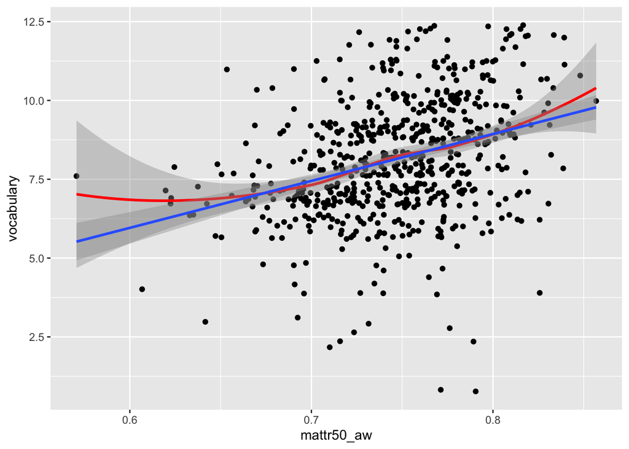

```r
ggplot(written_data, aes(mattr50_aw,vocabulary)) +
  geom_jitter() + #this can be used instead of geom_point() to account for the limted scale of "vocabulary"
  geom_smooth(method = "loess",color = "red") + #this is a line of best fit based on a moving average
  geom_smooth(method = "lm") #this is a line of best fit based on the enture dataset
```

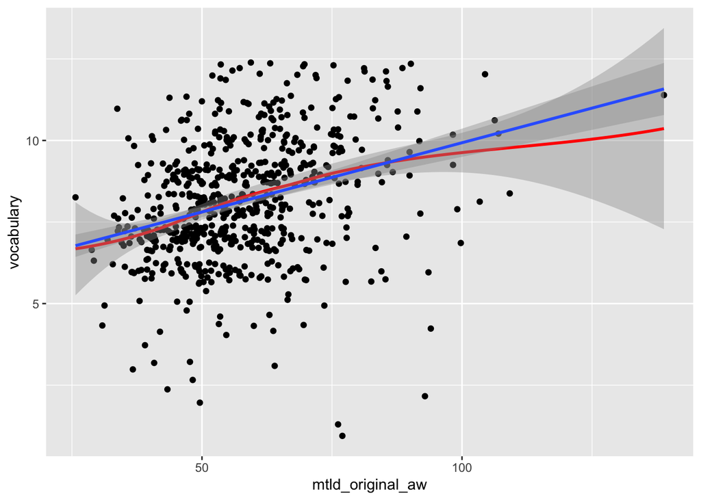

```r
ggplot(written_data, aes(mtld_original_aw,vocabulary)) +
  geom_jitter() + #this can be used instead of geom_point() to account for the limted scale of "vocabulary"
  geom_smooth(method = "loess",color = "red") + #this is a line of best fit based on a moving average
  geom_smooth(method = "lm") #this is a line of best fit based on the enture dataset
```

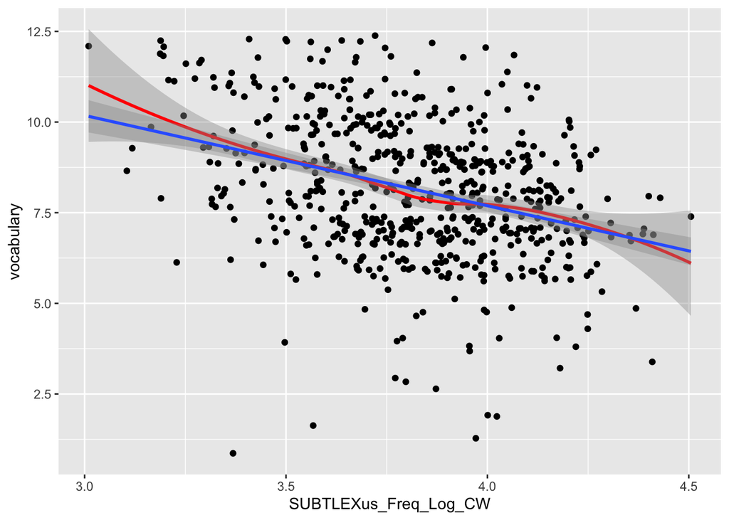

```r
ggplot(written_data, aes(SUBTLEXus_Freq_Log_CW,vocabulary)) +
  geom_jitter() + #this can be used instead of geom_point() to account for the limted scale of "vocabulary"
  geom_smooth(method = "loess",color = "red") + #this is a line of best fit based on a moving average
  geom_smooth(method = "lm") #this is a line of best fit based on the enture dataset
```

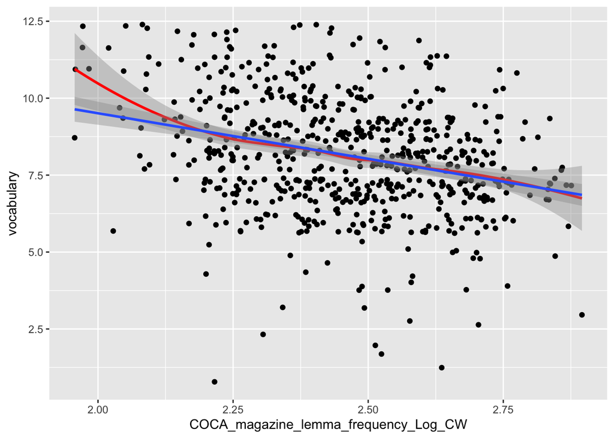

```r
ggplot(written_data, aes(COCA_magazine_lemma_frequency_Log_CW,vocabulary)) +
  geom_jitter() + #this can be used instead of geom_point() to account for the limted scale of "vocabulary"
  geom_smooth(method = "loess",color = "red") + #this is a line of best fit based on a moving average
  geom_smooth(method = "lm") #this is a line of best fit based on the enture dataset
```

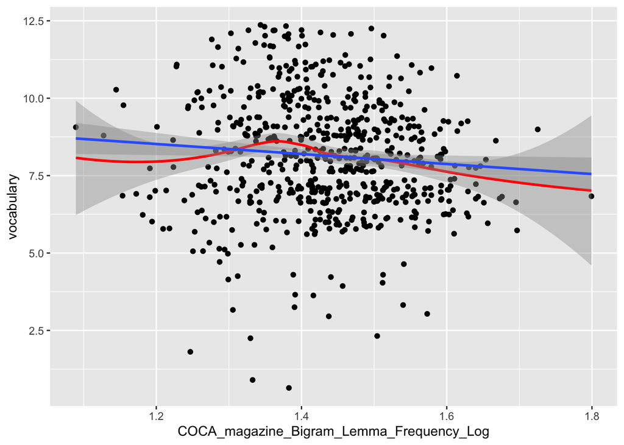

```r
ggplot(written_data, aes(COCA_magazine_Bigram_Lemma_Frequency_Log,vocabulary)) +
  geom_jitter() + #this can be used instead of geom_point() to account for the limted scale of "vocabulary"
  geom_smooth(method = "loess",color = "red") + #this is a line of best fit based on a moving average
  geom_smooth(method = "lm") #this is a line of best fit based on the enture dataset
```

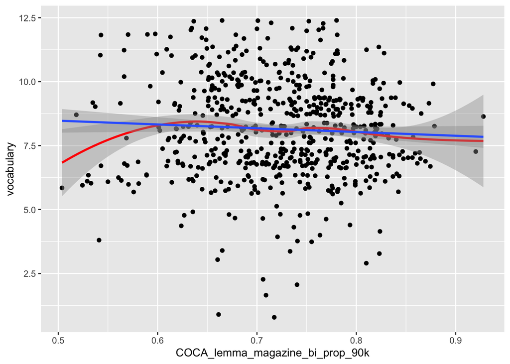

```r
ggplot(written_data, aes(COCA_lemma_magazine_bi_prop_90k,vocabulary)) +
  geom_jitter() + #this can be used instead of geom_point() to account for the limted scale of "vocabulary"
  geom_smooth(method = "loess",color = "red") + #this is a line of best fit based on a moving average
  geom_smooth(method = "lm") #this is a line of best fit based on the enture dataset
```

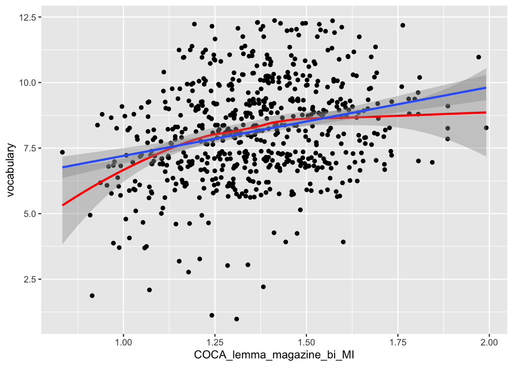

```r
ggplot(written_data, aes(COCA_lemma_magazine_bi_MI,vocabulary)) +
  geom_jitter() + #this can be used instead of geom_point() to account for the limted scale of "vocabulary"
  geom_smooth(method = "loess",color = "red") + #this is a line of best fit based on a moving average
  geom_smooth(method = "lm") #this is a line of best fit based on the enture dataset
```

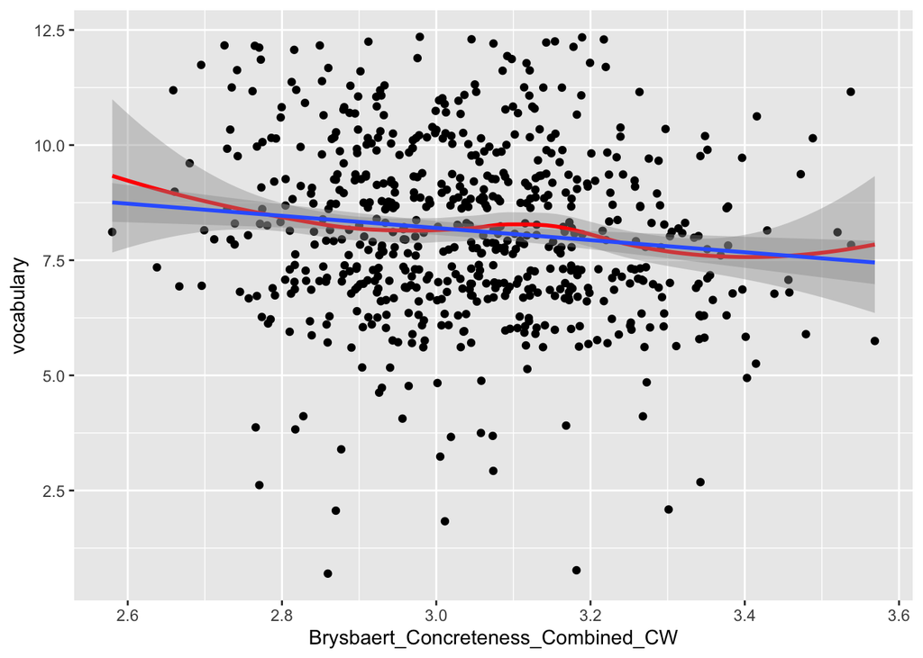

```r
ggplot(written_data, aes(Brysbaert_Concreteness_Combined_CW,vocabulary)) +
  geom_jitter() + #this can be used instead of geom_point() to account for the limted scale of "vocabulary"
  geom_smooth(method = "loess",color = "red") + #this is a line of best fit based on a moving average
  geom_smooth(method = "lm") #this is a line of best fit based on the enture dataset
```

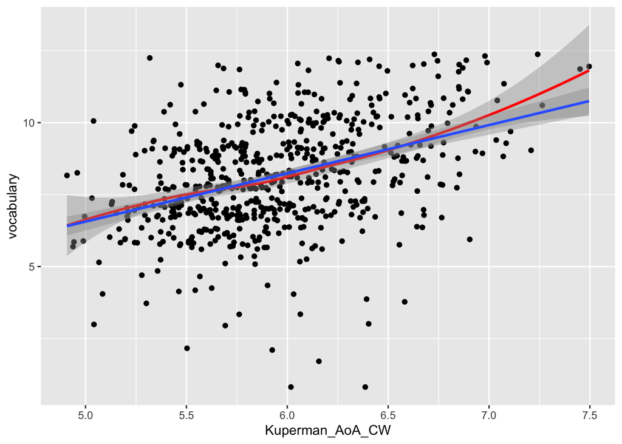

```r
ggplot(written_data, aes(Kuperman_AoA_CW,vocabulary)) +
  geom_jitter() + #this can be used instead of geom_point() to account for the limted scale of "vocabulary"
  geom_smooth(method = "loess",color = "red") + #this is a line of best fit based on a moving average
  geom_smooth(method = "lm") #this is a line of best fit based on the enture dataset
```

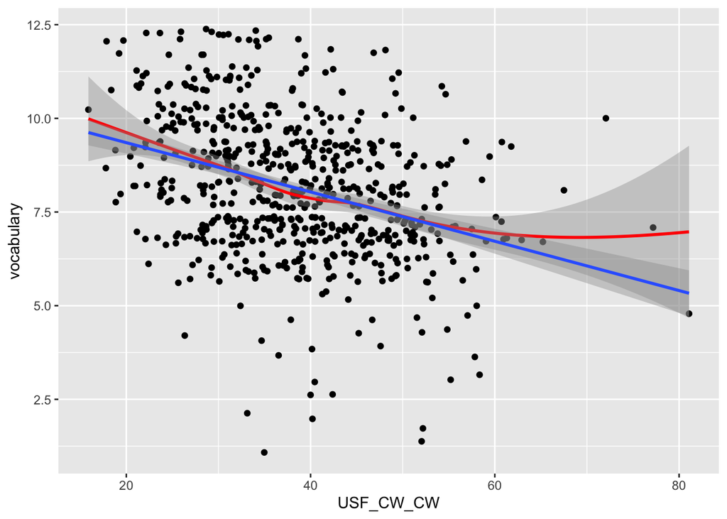

```r
ggplot(written_data, aes(USF_CW_CW,vocabulary)) +
  geom_jitter() + #this can be used instead of geom_point() to account for the limted scale of "vocabulary"
  geom_smooth(method = "loess",color = "red") + #this is a line of best fit based on a moving average
  geom_smooth(method = "lm") #this is a line of best fit based on the enture dataset
```

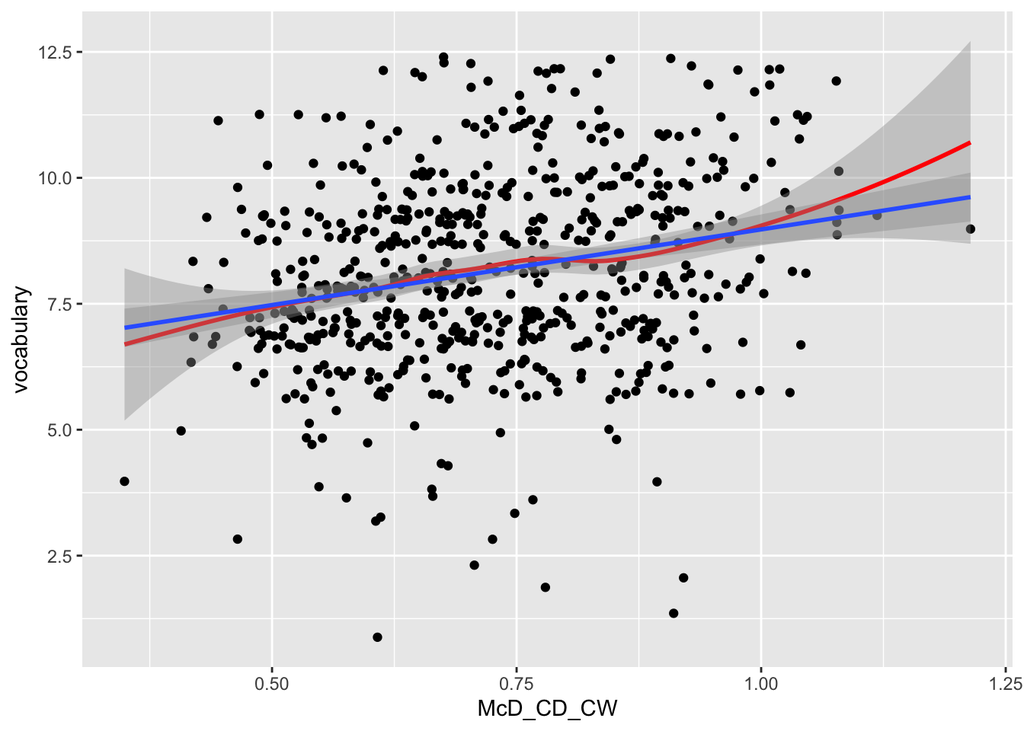

```r
ggplot(written_data, aes(McD_CD_CW,vocabulary)) +
  geom_jitter() + #this can be used instead of geom_point() to account for the limted scale of "vocabulary"
  geom_smooth(method = "loess",color = "red") + #this is a line of best fit based on a moving average
  geom_smooth(method = "lm") #this is a line of best fit based on the enture dataset
```

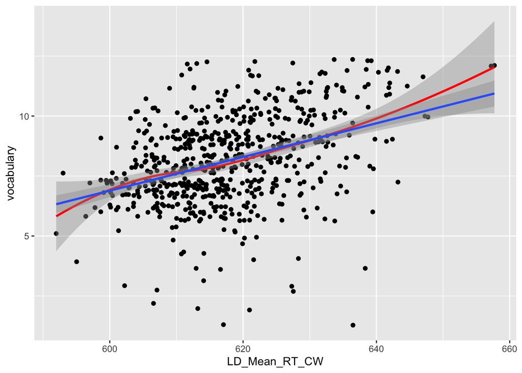

```r
ggplot(written_data, aes(LD_Mean_RT_CW,vocabulary)) +
  geom_jitter() + #this can be used instead of geom_point() to account for the limted scale of "vocabulary"
  geom_smooth(method = "loess",color = "red") + #this is a line of best fit based on a moving average
  geom_smooth(method = "lm") #this is a line of best fit based on the enture dataset
```

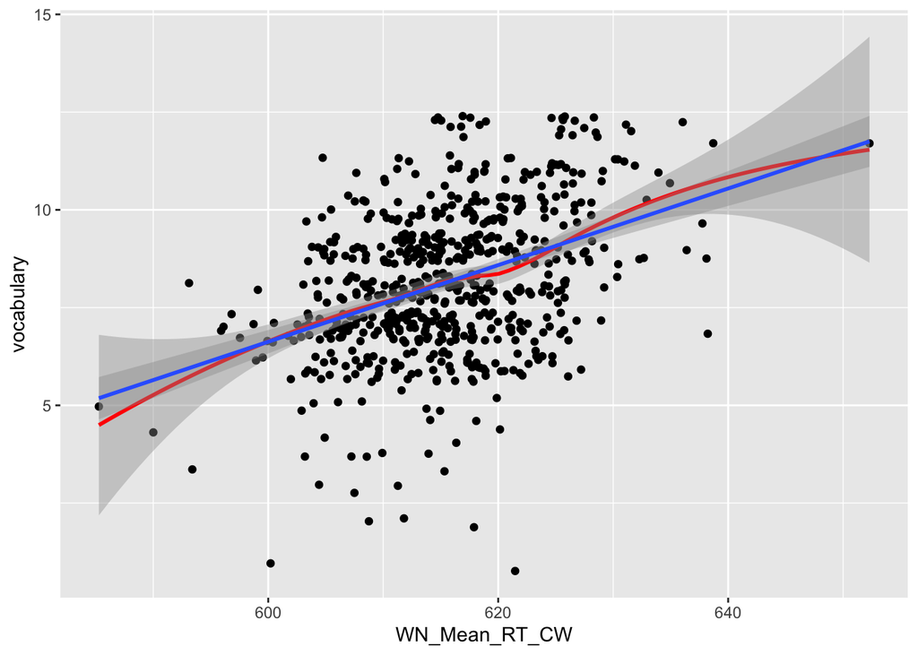

```r
ggplot(written_data, aes(WN_Mean_RT_CW,vocabulary)) +
  geom_jitter() + #this can be used instead of geom_point() to account for the limted scale of "vocabulary"
  geom_smooth(method = "loess",color = "red") + #this is a line of best fit based on a moving average
  geom_smooth(method = "lm") #this is a line of best fit based on the enture dataset
```

## Step 5 - Prepare data for correlation matrix

### Method 1: Use column numbers

```r
#written_data_num <- written_data[, -c(1,2,3,4)] #exclude categorical variables
```

### Method 2: Use variable names with the package dplyr()

```r
#install.packages("dplyr")
library(dplyr)
written_data_num <- dplyr::select(written_data, -filename,-participant,-country,-topic)
summary(written_data_num) #check dataset
```

```
##    vocabulary         nwords        mattr50_aw     mtld_original_aw
##  Min.   : 1.000   Min.   :178.0   Min.   :0.5706   Min.   : 25.68
##  1st Qu.: 7.000   1st Qu.:206.0   1st Qu.:0.7200   1st Qu.: 48.09
##  Median : 8.000   Median :218.0   Median :0.7486   Median : 55.76
##  Mean   : 8.144   Mean   :228.4   Mean   :0.7468   Mean   : 57.93
##  3rd Qu.: 9.000   3rd Qu.:243.8   3rd Qu.:0.7764   3rd Qu.: 65.51
##  Max.   :12.000   Max.   :400.0   Max.   :0.8568   Max.   :138.83
##  SUBTLEXus_Freq_Log_CW COCA_magazine_lemma_frequency_Log_CW
##  Min.   :3.010         Min.   :1.957
##  1st Qu.:3.644         1st Qu.:2.324
##  Median :3.822         Median :2.472
##  Mean   :3.819         Mean   :2.461
##  3rd Qu.:4.006         3rd Qu.:2.607
##  Max.   :4.505         Max.   :2.896
##  COCA_magazine_Bigram_Lemma_Frequency_Log COCA_lemma_magazine_bi_prop_90k
##  Min.   :1.089                            Min.   :0.5038
##  1st Qu.:1.362                            1st Qu.:0.6702
##  Median :1.435                            Median :0.7297
##  Mean   :1.433                            Mean   :0.7239
##  3rd Qu.:1.504                            3rd Qu.:0.7773
##  Max.   :1.799                            Max.   :0.9279
##  COCA_lemma_magazine_bi_MI Brysbaert_Concreteness_Combined_CW Kuperman_AoA_CW
##  Min.   :0.833             Min.   :2.580                      Min.   :4.908
##  1st Qu.:1.222             1st Qu.:2.922                      1st Qu.:5.623
##  Median :1.357             Median :3.038                      Median :5.879
##  Mean   :1.358             Mean   :3.043                      Mean   :5.943
##  3rd Qu.:1.491             3rd Qu.:3.157                      3rd Qu.:6.231
##  Max.   :1.991             Max.   :3.569                      Max.   :7.496
##    USF_CW_CW       McD_CD_CW      LD_Mean_RT_CW   WN_Mean_RT_CW
##  Min.   :15.89   Min.   :0.3492   Min.   :592.0   Min.   :585.3
##  1st Qu.:31.03   1st Qu.:0.6077   1st Qu.:610.9   1st Qu.:610.6
##  Median :38.06   Median :0.7075   Median :616.7   Median :615.1
##  Mean   :38.35   Mean   :0.7229   Mean   :617.9   Mean   :615.5
##  3rd Qu.:45.14   3rd Qu.:0.8435   3rd Qu.:624.5   3rd Qu.:620.4
##  Max.   :81.08   Max.   :1.2141   Max.   :657.7   Max.   :652.3
```

## Step 6 - Check for collinearity using a correlation matrix

```r
corr_matrix <- cor(written_data_num)
#View(corr_matrix) #view nicely formatted correlation matrix in R studio
print(corr_matrix)
```

```
##                                           vocabulary      nwords mattr50_aw
## vocabulary                                1.00000000  0.21243798  0.3334289
## nwords                                    0.21243798  1.00000000  0.1344763
## mattr50_aw                                0.33342892  0.13447632  1.0000000
## mtld_original_aw                          0.32203263  0.11920982  0.8858730
## SUBTLEXus_Freq_Log_CW                    -0.34688513 -0.14622614 -0.3356758
## COCA_magazine_lemma_frequency_Log_CW     -0.29326710 -0.06913816 -0.2864149
## COCA_magazine_Bigram_Lemma_Frequency_Log -0.08974643 -0.05436329 -0.3111942
## COCA_lemma_magazine_bi_prop_90k          -0.05767377  0.02459790 -0.2258166
## COCA_lemma_magazine_bi_MI                 0.27049100 -0.05491171  0.1751284
## Brysbaert_Concreteness_Combined_CW       -0.11978713 -0.15283982 -0.2302148
## Kuperman_AoA_CW                           0.40834655  0.23159103  0.3593317
## USF_CW_CW                                -0.34517965 -0.13138797 -0.3549031
## McD_CD_CW                                 0.24009203  0.03604346  0.2512863
## LD_Mean_RT_CW                             0.38469974  0.23107325  0.3814839
## WN_Mean_RT_CW                             0.40326092  0.18225617  0.3689343
##                                          mtld_original_aw SUBTLEXus_Freq_Log_CW
## vocabulary                                      0.3220326           -0.34688513
## nwords                                          0.1192098           -0.14622614
## mattr50_aw                                      0.8858730           -0.33567582
## mtld_original_aw                                1.0000000           -0.35828421
## SUBTLEXus_Freq_Log_CW                          -0.3582842            1.00000000
## COCA_magazine_lemma_frequency_Log_CW           -0.3123867            0.92252807
## COCA_magazine_Bigram_Lemma_Frequency_Log       -0.2794126            0.35837636
## COCA_lemma_magazine_bi_prop_90k                -0.2609882            0.70623649
## COCA_lemma_magazine_bi_MI                       0.1806908            0.00567931
## Brysbaert_Concreteness_Combined_CW             -0.2036848           -0.29130351
## Kuperman_AoA_CW                                 0.3799419           -0.76898504
## USF_CW_CW                                      -0.3640205            0.73116256
## McD_CD_CW                                       0.2743242           -0.84107434
## LD_Mean_RT_CW                                   0.3995166           -0.69459700
## WN_Mean_RT_CW                                   0.3813609           -0.71700033
##                                          COCA_magazine_lemma_frequency_Log_CW
## vocabulary                                                        -0.29326710
## nwords                                                            -0.06913816
## mattr50_aw                                                        -0.28641490
## mtld_original_aw                                                  -0.31238671
## SUBTLEXus_Freq_Log_CW                                              0.92252807
## COCA_magazine_lemma_frequency_Log_CW                               1.00000000
## COCA_magazine_Bigram_Lemma_Frequency_Log                           0.28656322
```

[output cut: 105 more lines]

```
## vocabulary                                  0.40326092
## nwords                                      0.18225617
## mattr50_aw                                  0.36893430
## mtld_original_aw                            0.38136087
## SUBTLEXus_Freq_Log_CW                      -0.71700033
## COCA_magazine_lemma_frequency_Log_CW       -0.62784788
## COCA_magazine_Bigram_Lemma_Frequency_Log   -0.30640588
## COCA_lemma_magazine_bi_prop_90k            -0.41174704
## COCA_lemma_magazine_bi_MI                   0.16914286
## Brysbaert_Concreteness_Combined_CW         -0.02189382
## Kuperman_AoA_CW                             0.72939374
## USF_CW_CW                                  -0.62163914
## McD_CD_CW                                   0.52647499
## LD_Mean_RT_CW                               0.77411601
## WN_Mean_RT_CW                               1.00000000
```

## Step 7 - Examine correlation matrix, select variables based criteria:

- Remove any variables that demonstrate a negligible relationship with vocabulary score (|r| < .100)
- For each conceptual category, check for multicollinearity (|r| > .700).
- For any collinear pairs, choose index with strongest theoretical rationale OR strongest correlation with vocabulary score

## Step 8 - Create refined dataset, recheck collinearity

Remove variables identified in Step 7 and double check collinearity across conceptual categories - create refined dataset

```r
written_data_refined1 <- dplyr::select(written_data, -nwords, -mtld_original_aw, -COCA_magazine_lemma_frequency_Log_CW, -COCA_magazine_Bigram_Lemma_Frequency_Log, -COCA_lemma_magazine_bi_prop_90k, -LD_Mean_RT_CW)
summary(written_data_refined1)
```

```
##    filename         participant          country             topic
##  Length:638         Length:638         Length:638         Length:638
##  Class :character   Class :character   Class :character   Class :character
##  Mode  :character   Mode  :character   Mode  :character   Mode  :character
##
##
##
##    vocabulary       mattr50_aw     SUBTLEXus_Freq_Log_CW
##  Min.   : 1.000   Min.   :0.5706   Min.   :3.010
##  1st Qu.: 7.000   1st Qu.:0.7200   1st Qu.:3.644
##  Median : 8.000   Median :0.7486   Median :3.822
##  Mean   : 8.144   Mean   :0.7468   Mean   :3.819
##  3rd Qu.: 9.000   3rd Qu.:0.7764   3rd Qu.:4.006
##  Max.   :12.000   Max.   :0.8568   Max.   :4.505
##  COCA_lemma_magazine_bi_MI Brysbaert_Concreteness_Combined_CW Kuperman_AoA_CW
##  Min.   :0.833             Min.   :2.580                      Min.   :4.908
##  1st Qu.:1.222             1st Qu.:2.922                      1st Qu.:5.623
##  Median :1.357             Median :3.038                      Median :5.879
##  Mean   :1.358             Mean   :3.043                      Mean   :5.943
##  3rd Qu.:1.491             3rd Qu.:3.157                      3rd Qu.:6.231
##  Max.   :1.991             Max.   :3.569                      Max.   :7.496
##    USF_CW_CW       McD_CD_CW      WN_Mean_RT_CW
##  Min.   :15.89   Min.   :0.3492   Min.   :585.3
##  1st Qu.:31.03   1st Qu.:0.6077   1st Qu.:610.6
##  Median :38.06   Median :0.7075   Median :615.1
##  Mean   :38.35   Mean   :0.7229   Mean   :615.5
##  3rd Qu.:45.14   3rd Qu.:0.8435   3rd Qu.:620.4
##  Max.   :81.08   Max.   :1.2141   Max.   :652.3
```

- Remove categorical variables from refined dataset, check correlation matrix

```r
written_data_refined1_num <-  dplyr::select(written_data_refined1, -filename, -participant, -country, -topic)
corr_matrix_refined <- cor(written_data_refined1_num)
#View(corr_matrix_refined) #view nicely formatted correlation matrix in R studio
print(corr_matrix_refined)
```

```
##                                    vocabulary mattr50_aw SUBTLEXus_Freq_Log_CW
## vocabulary                          1.0000000  0.3334289           -0.34688513
## mattr50_aw                          0.3334289  1.0000000           -0.33567582
## SUBTLEXus_Freq_Log_CW              -0.3468851 -0.3356758            1.00000000
## COCA_lemma_magazine_bi_MI           0.2704910  0.1751284            0.00567931
## Brysbaert_Concreteness_Combined_CW -0.1197871 -0.2302148           -0.29130351
## Kuperman_AoA_CW                     0.4083466  0.3593317           -0.76898504
## USF_CW_CW                          -0.3451796 -0.3549031            0.73116256
## McD_CD_CW                           0.2400920  0.2512863           -0.84107434
## WN_Mean_RT_CW                       0.4032609  0.3689343           -0.71700033
##                                    COCA_lemma_magazine_bi_MI
## vocabulary                                        0.27049100
## mattr50_aw                                        0.17512843
## SUBTLEXus_Freq_Log_CW                             0.00567931
## COCA_lemma_magazine_bi_MI                         1.00000000
## Brysbaert_Concreteness_Combined_CW               -0.12712577
## Kuperman_AoA_CW                                   0.05229913
## USF_CW_CW                                        -0.05156003
## McD_CD_CW                                         0.07112567
## WN_Mean_RT_CW                                     0.16914286
##                                    Brysbaert_Concreteness_Combined_CW
## vocabulary                                                -0.11978713
## mattr50_aw                                                -0.23021481
## SUBTLEXus_Freq_Log_CW                                     -0.29130351
## COCA_lemma_magazine_bi_MI                                 -0.12712577
## Brysbaert_Concreteness_Combined_CW                         1.00000000
## Kuperman_AoA_CW                                           -0.14639179
## USF_CW_CW                                                 -0.06350324
## McD_CD_CW                                                  0.37359320
## WN_Mean_RT_CW                                             -0.02189382
##                                    Kuperman_AoA_CW   USF_CW_CW   McD_CD_CW
## vocabulary                              0.40834655 -0.34517965  0.24009203
## mattr50_aw                              0.35933166 -0.35490315  0.25128631
## SUBTLEXus_Freq_Log_CW                  -0.76898504  0.73116256 -0.84107434
## COCA_lemma_magazine_bi_MI               0.05229913 -0.05156003  0.07112567
## Brysbaert_Concreteness_Combined_CW     -0.14639179 -0.06350324  0.37359320
## Kuperman_AoA_CW                         1.00000000 -0.63663898  0.53439475
## USF_CW_CW                              -0.63663898  1.00000000 -0.66955178
## McD_CD_CW                               0.53439475 -0.66955178  1.00000000
## WN_Mean_RT_CW                           0.72939374 -0.62163914  0.52647499
##                                    WN_Mean_RT_CW
## vocabulary                            0.40326092
## mattr50_aw                            0.36893430
## SUBTLEXus_Freq_Log_CW                -0.71700033
## COCA_lemma_magazine_bi_MI             0.16914286
## Brysbaert_Concreteness_Combined_CW   -0.02189382
## Kuperman_AoA_CW                       0.72939374
## USF_CW_CW                            -0.62163914
## McD_CD_CW                             0.52647499
## WN_Mean_RT_CW                         1.00000000
```

## Step 9 - Recheck multicollinearity

**Model optimization approach** - choose variable with strongest correlation (with vocabulary score) - remove any collinear variables (|r| > .700) - repeat with variable with next strongest correlation (etc.)

**Conceptual approach** - choose most theoretically/conceptually important variable - remove any collinear variables (|r| > .700) - repeat with second most theoretically/conceptually important variable (etc.)

## Step 10 - Refine dataset again

(I used the model optimization approach)

```r
written_data_refined2 <- dplyr::select(written_data_refined1, -SUBTLEXus_Freq_Log_CW,-WN_Mean_RT_CW)
summary(written_data_refined2)
```

```
##    filename         participant          country             topic
##  Length:638         Length:638         Length:638         Length:638
##  Class :character   Class :character   Class :character   Class :character
##  Mode  :character   Mode  :character   Mode  :character   Mode  :character
##
##
##
##    vocabulary       mattr50_aw     COCA_lemma_magazine_bi_MI
##  Min.   : 1.000   Min.   :0.5706   Min.   :0.833
##  1st Qu.: 7.000   1st Qu.:0.7200   1st Qu.:1.222
##  Median : 8.000   Median :0.7486   Median :1.357
##  Mean   : 8.144   Mean   :0.7468   Mean   :1.358
##  3rd Qu.: 9.000   3rd Qu.:0.7764   3rd Qu.:1.491
##  Max.   :12.000   Max.   :0.8568   Max.   :1.991
##  Brysbaert_Concreteness_Combined_CW Kuperman_AoA_CW   USF_CW_CW
##  Min.   :2.580                      Min.   :4.908   Min.   :15.89
##  1st Qu.:2.922                      1st Qu.:5.623   1st Qu.:31.03
##  Median :3.038                      Median :5.879   Median :38.06
##  Mean   :3.043                      Mean   :5.943   Mean   :38.35
##  3rd Qu.:3.157                      3rd Qu.:6.231   3rd Qu.:45.14
##  Max.   :3.569                      Max.   :7.496   Max.   :81.08
##    McD_CD_CW
##  Min.   :0.3492
##  1st Qu.:0.6077
##  Median :0.7075
##  Mean   :0.7229
##  3rd Qu.:0.8435
##  Max.   :1.2141
```

## Step 11 - Run multiple regression

### Option 1 - Simple multiple regression

(easy to run, but results likely inflated)

```r
#run model
model1 <- lm(vocabulary ~ mattr50_aw + COCA_lemma_magazine_bi_MI + Brysbaert_Concreteness_Combined_CW + Kuperman_AoA_CW + USF_CW_CW + McD_CD_CW, data = written_data_refined2)
summary(model1)
```

```
##
## Call:
## lm(formula = vocabulary ~ mattr50_aw + COCA_lemma_magazine_bi_MI +
##     Brysbaert_Concreteness_Combined_CW + Kuperman_AoA_CW + USF_CW_CW +
##     McD_CD_CW, data = written_data_refined2)
##
## Residuals:
##     Min      1Q  Median      3Q     Max
## -7.6792 -1.0174  0.0227  1.0849  4.4903
##
## Coefficients:
##                                     Estimate Std. Error t value Pr(>|t|)
## (Intercept)                        -5.552687   2.636660  -2.106  0.03560 *
## mattr50_aw                          7.073872   1.737833   4.071 5.29e-05 ***
## COCA_lemma_magazine_bi_MI           2.181992   0.340378   6.411 2.84e-10 ***
## Brysbaert_Concreteness_Combined_CW  0.003965   0.475967   0.008  0.99336
## Kuperman_AoA_CW                     1.170503   0.200740   5.831 8.80e-09 ***
## USF_CW_CW                          -0.025762   0.009939  -2.592  0.00976 **
## McD_CD_CW                          -0.733046   0.694538  -1.055  0.29163
## ---
## Signif. codes:  0 '***' 0.001 '**' 0.01 '*' 0.05 '.' 0.1 ' ' 1
##
## Residual standard error: 1.633 on 631 degrees of freedom
## Multiple R-squared:  0.2626, Adjusted R-squared:  0.2556
## F-statistic: 37.46 on 6 and 631 DF,  p-value: < 2.2e-16
```

```r
print(car::vif(model1)) #checks multicollinearity within model rule of thumb: vif < 5 is OK
```

```
##                         mattr50_aw          COCA_lemma_magazine_bi_MI
##                           1.296833                           1.054983
## Brysbaert_Concreteness_Combined_CW                    Kuperman_AoA_CW
##                           1.599536                           2.044208
##                          USF_CW_CW                          McD_CD_CW
##                           2.326323                           2.643401
```

```r
#install.packages('relaimpo')
relaimpo::calc.relimp(model1) #gets relative importance metrics for model variables
```

```
## Response variable: vocabulary
## Total response variance: 3.580429
## Analysis based on 638 observations
##
## 6 Regressors:
## mattr50_aw COCA_lemma_magazine_bi_MI Brysbaert_Concreteness_Combined_CW Kuperman_AoA_CW USF_CW_CW McD_CD_CW
## Proportion of variance explained by model: 26.26%
## Metrics are not normalized (rela=FALSE).
##
## Relative importance metrics:
##
##                                            lmg
## mattr50_aw                         0.049720199
## COCA_lemma_magazine_bi_MI          0.055662007
## Brysbaert_Concreteness_Combined_CW 0.008314285
## Kuperman_AoA_CW                    0.083792381
## USF_CW_CW                          0.046142086
## McD_CD_CW                          0.018988233
##
## Average coefficients for different model sizes:
##
##                                             1X         2Xs         3Xs
## mattr50_aw                         14.88462902 12.18950732  9.99758646
## COCA_lemma_magazine_bi_MI           2.62216429  2.39667591  2.26165132
## Brysbaert_Concreteness_Combined_CW -1.31873950 -1.27552060 -1.11735026
## Kuperman_AoA_CW                     1.67713675  1.50738236  1.35668910
## USF_CW_CW                          -0.06579652 -0.05426575 -0.04395497
## McD_CD_CW                           3.00027568  1.91632582  1.14239201
##                                            4Xs         5Xs          6Xs
## mattr50_aw                          8.49339821  7.61337601  7.073872319
## COCA_lemma_magazine_bi_MI           2.19960933  2.17743512  2.181991873
## Brysbaert_Concreteness_Combined_CW -0.82572059 -0.43376875  0.003965315
## Kuperman_AoA_CW                     1.25060344  1.19130035  1.170503242
## USF_CW_CW                          -0.03566439 -0.02963427 -0.025762100
## McD_CD_CW                           0.48548886 -0.13321439 -0.733045810
```

Then, we will check for prompt differences visually

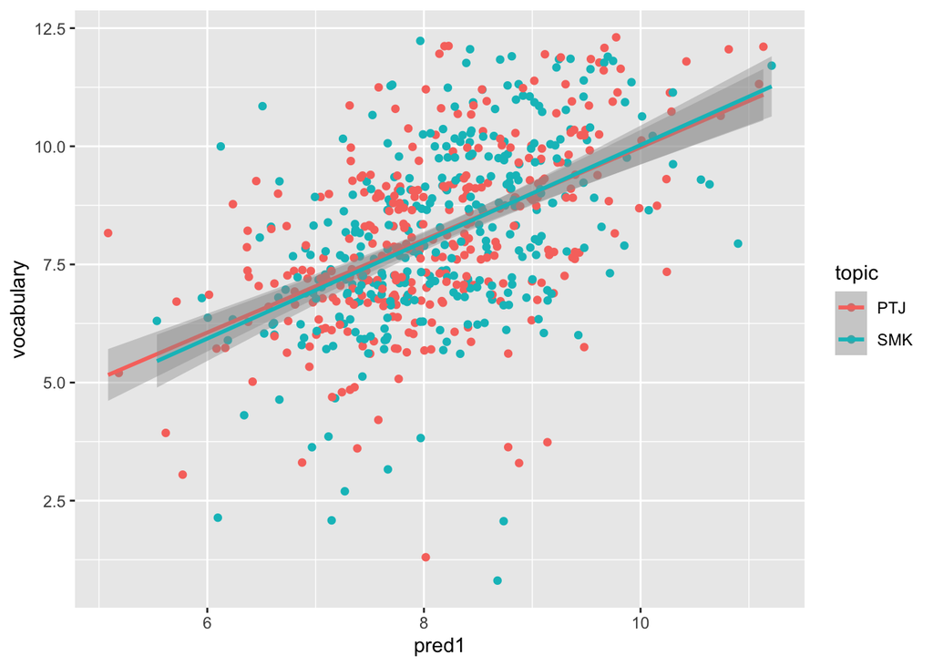

```r
#visualize prompt differences:
written_data_refined2$pred1 <- predict(model1,written_data_refined2)
ggplot(written_data_refined2, aes(pred1,vocabulary)) +
  geom_jitter(aes(color = topic)) + #this can be used instead of geom_point() to account for the limited scale of "vocabulary"
  geom_smooth(method = "lm", aes(color = topic)) #this is a line of best fit based on the entire dataset
```

And by comparing effect size (R^2)

```r
#evaluate promt differences
ptj <- written_data_refined2 %>% dplyr::filter(topic == "PTJ")
smk <- written_data_refined2 %>% dplyr::filter(topic == "SMK")

print(cor(ptj$vocabulary,ptj$pred1)^2)
```

```
## [1] 0.2856019
```

```r
print(cor(smk$vocabulary,smk$pred1)^2)
```

```
## [1] 0.2417484
```

### Option 2 - Training/Test sets

(better argument for generalizability, but random selection can be unpredictable)

First, we need to organize our data:

```r
set.seed(123) # for reproducible results (seed is for random number generator)
sample.size <- floor(0.75 * nrow(written_data_refined2)) #get number of rows for 75% of data
train.index <- sample(seq_len(nrow(written_data_refined2)), size = sample.size) #get random list of rows (75% of the data)
train <- written_data_refined2[train.index, ] #training set
test <- written_data_refined2[- train.index, ] #test set
```

Then, we create a model using the training set:

```r
#create model with train set
model2 <- lm(vocabulary ~ mattr50_aw + COCA_lemma_magazine_bi_MI + Brysbaert_Concreteness_Combined_CW + Kuperman_AoA_CW + USF_CW_CW + McD_CD_CW, data = train)
summary(model2)
```

```
##
## Call:
## lm(formula = vocabulary ~ mattr50_aw + COCA_lemma_magazine_bi_MI +
##     Brysbaert_Concreteness_Combined_CW + Kuperman_AoA_CW + USF_CW_CW +
##     McD_CD_CW, data = train)
##
## Residuals:
##     Min      1Q  Median      3Q     Max
## -7.7164 -0.9905 -0.0315  1.0491  4.2925
##
## Coefficients:
##                                    Estimate Std. Error t value Pr(>|t|)
## (Intercept)                        -6.65477    3.06060  -2.174  0.03018 *
## mattr50_aw                          5.89261    2.00940   2.933  0.00353 **
## COCA_lemma_magazine_bi_MI           2.09629    0.39257   5.340 1.45e-07 ***
## Brysbaert_Concreteness_Combined_CW  0.18534    0.53853   0.344  0.73088
## Kuperman_AoA_CW                     1.34242    0.23718   5.660 2.64e-08 ***
## USF_CW_CW                          -0.01956    0.01174  -1.667  0.09621 .
## McD_CD_CW                          -0.43582    0.81272  -0.536  0.59204
## ---
## Signif. codes:  0 '***' 0.001 '**' 0.01 '*' 0.05 '.' 0.1 ' ' 1
##
## Residual standard error: 1.648 on 471 degrees of freedom
## Multiple R-squared:  0.2644, Adjusted R-squared:  0.2551
## F-statistic: 28.22 on 6 and 471 DF,  p-value: < 2.2e-16
```

```r
print(car::vif(model2))
```

```
##                         mattr50_aw          COCA_lemma_magazine_bi_MI
##                           1.326937                           1.062381
## Brysbaert_Concreteness_Combined_CW                    Kuperman_AoA_CW
##                           1.593988                           2.054689
##                          USF_CW_CW                          McD_CD_CW
##                           2.411108                           2.648912
```

```r
print(relaimpo::calc.relimp(model2)) #gets relative importance metrics for model variables
```

```
## Response variable: vocabulary
## Total response variance: 3.648044
## Analysis based on 478 observations
##
## 6 Regressors:
## mattr50_aw COCA_lemma_magazine_bi_MI Brysbaert_Concreteness_Combined_CW Kuperman_AoA_CW USF_CW_CW McD_CD_CW
## Proportion of variance explained by model: 26.44%
## Metrics are not normalized (rela=FALSE).
##
## Relative importance metrics:
##
##                                            lmg
## mattr50_aw                         0.041825783
## COCA_lemma_magazine_bi_MI          0.052773181
## Brysbaert_Concreteness_Combined_CW 0.005523292
## Kuperman_AoA_CW                    0.096838088
## USF_CW_CW                          0.044498003
## McD_CD_CW                          0.022991314
##
## Average coefficients for different model sizes:
##
##                                             1X         2Xs         3Xs
## mattr50_aw                         14.07808744 11.17779967  8.87065401
## COCA_lemma_magazine_bi_MI           2.59829784  2.32979047  2.17817956
## Brysbaert_Concreteness_Combined_CW -0.96023215 -0.95341593 -0.82812058
## Kuperman_AoA_CW                     1.80443526  1.63821871  1.49861721
## USF_CW_CW                          -0.06700005 -0.05359918 -0.04158172
## McD_CD_CW                           3.38186897  2.27725507  1.47631073
##                                           4Xs         5Xs        6Xs
## mattr50_aw                          7.3180226  6.42917642  5.8926089
## COCA_lemma_magazine_bi_MI           2.1146765  2.09330897  2.0962881
## Brysbaert_Concreteness_Combined_CW -0.5670051 -0.20877797  0.1853419
## Kuperman_AoA_CW                     1.4060738  1.35774276  1.3424163
## USF_CW_CW                          -0.0317994 -0.02449243 -0.0195633
## McD_CD_CW                           0.7942915  0.16148391 -0.4358193
```

And evaluate its stability on the test set:

```r
#test model on test set
test$pred1 <- predict(model2, test)
cor(test$vocabulary,test$pred1)^2 #get R^2
```

```
## [1] 0.2481816
```

### Option 3: Cross-validation (Ten-fold)

Randomly splits the data into ten sections, then iteratively uses 90% to train a model that is then tested on the remaining 10% of the data. This is repeated until all sections of the dataset have been used as the test set.

```r
#install.packages("caret")
library(caret)
ctrl.tenfold <- trainControl(method="cv", number=10) #create method

model3 <- train(vocabulary ~ mattr50_aw + COCA_lemma_magazine_bi_MI + Brysbaert_Concreteness_Combined_CW + Kuperman_AoA_CW + USF_CW_CW + McD_CD_CW, data = written_data_refined2, method = "lm", trControl = ctrl.tenfold)
summary(model3) #show full model
```

```
##
## Call:
## lm(formula = .outcome ~ ., data = dat)
##
## Residuals:
##     Min      1Q  Median      3Q     Max
## -7.6792 -1.0174  0.0227  1.0849  4.4903
##
## Coefficients:
##                                     Estimate Std. Error t value Pr(>|t|)
## (Intercept)                        -5.552687   2.636660  -2.106  0.03560 *
## mattr50_aw                          7.073872   1.737833   4.071 5.29e-05 ***
## COCA_lemma_magazine_bi_MI           2.181992   0.340378   6.411 2.84e-10 ***
## Brysbaert_Concreteness_Combined_CW  0.003965   0.475967   0.008  0.99336
## Kuperman_AoA_CW                     1.170503   0.200740   5.831 8.80e-09 ***
## USF_CW_CW                          -0.025762   0.009939  -2.592  0.00976 **
## McD_CD_CW                          -0.733046   0.694538  -1.055  0.29163
## ---
## Signif. codes:  0 '***' 0.001 '**' 0.01 '*' 0.05 '.' 0.1 ' ' 1
##
## Residual standard error: 1.633 on 631 degrees of freedom
## Multiple R-squared:  0.2626, Adjusted R-squared:  0.2556
## F-statistic: 37.46 on 6 and 631 DF,  p-value: < 2.2e-16
```

```r
print(model3) #show cross-validated results
```

```
## Linear Regression
##
## 638 samples
##   6 predictor
##
## No pre-processing
## Resampling: Cross-Validated (10 fold)
## Summary of sample sizes: 575, 573, 575, 573, 575, 575, ...
## Resampling results:
##
##   RMSE      Rsquared   MAE
##   1.635803  0.2615039  1.259723
##
## Tuning parameter 'intercept' was held constant at a value of TRUE
```

### Option 4: Cross-validation (LOOCV)

This is the same as Option 3, except that the model is trained on ALL of the data (except one row) and then tested on the remaining row. This is repeated until all data points have been used as the test data.

```r
ctrl.loocv <- trainControl(method = "LOOCV") #create method

model4 <- train(vocabulary ~ mattr50_aw + COCA_lemma_magazine_bi_MI + Brysbaert_Concreteness_Combined_CW + Kuperman_AoA_CW + USF_CW_CW + McD_CD_CW, data = written_data_refined2, method = "lm", trControl = ctrl.loocv)
summary(model4) #show full model
```

```
##
## Call:
## lm(formula = .outcome ~ ., data = dat)
##
## Residuals:
##     Min      1Q  Median      3Q     Max
## -7.6792 -1.0174  0.0227  1.0849  4.4903
##
## Coefficients:
##                                     Estimate Std. Error t value Pr(>|t|)
## (Intercept)                        -5.552687   2.636660  -2.106  0.03560 *
## mattr50_aw                          7.073872   1.737833   4.071 5.29e-05 ***
## COCA_lemma_magazine_bi_MI           2.181992   0.340378   6.411 2.84e-10 ***
## Brysbaert_Concreteness_Combined_CW  0.003965   0.475967   0.008  0.99336
## Kuperman_AoA_CW                     1.170503   0.200740   5.831 8.80e-09 ***
## USF_CW_CW                          -0.025762   0.009939  -2.592  0.00976 **
## McD_CD_CW                          -0.733046   0.694538  -1.055  0.29163
## ---
## Signif. codes:  0 '***' 0.001 '**' 0.01 '*' 0.05 '.' 0.1 ' ' 1
##
## Residual standard error: 1.633 on 631 degrees of freedom
## Multiple R-squared:  0.2626, Adjusted R-squared:  0.2556
## F-statistic: 37.46 on 6 and 631 DF,  p-value: < 2.2e-16
```

```r
print(model4) #show cross-validated results
```

```
## Linear Regression
##
## 638 samples
##   6 predictor
##
## No pre-processing
## Resampling: Leave-One-Out Cross-Validation
## Summary of sample sizes: 637, 637, 637, 637, 637, 637, ...
## Resampling results:
##
##   RMSE      Rsquared   MAE
##   1.641686  0.2463573  1.259309
##
## Tuning parameter 'intercept' was held constant at a value of TRUE
```